# RQ1: What is the impact of model architecture and training environment on image classification training concerning energy consumption and GPU usage?

Santiago del Rey

## Load and preprocess data

We load the data from the parquet file, filter out the `inception_v3` architecture and the `Desktop Normal User` training environment, and normalize the energy consumption by the total number of images seen during training (converting MJ to J). We also prepare the `gpu_usage` variable.

```r
df <- read_parquet("data/metrics/processed/clean-dl-training-energy-consumption-dataset.gzip") %>%
  filter(architecture != "inception_v3" & `training environment` != "Desktop Normal User") %>%
  mutate(
    energy = (`energy (MJ)` * 1000000) / `total seen images`, # Convert MJ to J and normalize by total seen images
    training_environment = factor(`training environment`, levels = c("Desktop ML Engineer", "Server")),
    architecture = case_match(
      architecture,
      "mobilenet_v2" ~ "Mobilenet V2",
      "nasnet_mobile" ~ "NASNet Mobile",
      "resnet50" ~ "ResNet50",
      "xception" ~ "Xception",
      "vgg16" ~ "VGG16"
    ),
    architecture = factor(architecture, levels = c("Mobilenet V2", "NASNet Mobile", "ResNet50", "Xception", "VGG16")),
    gpu_usage = `gpu usage (%)`
  ) %>%
  select(energy, gpu_usage, architecture, training_environment)
```

### Outlier filtering functions

```r
# Define a function to filter outliers of a given variable on an input data frame
filter_outliers <- function(df, variable) {
  df %>%
    group_by(architecture, training_environment) %>%
    mutate(
      Q1 = quantile(!!sym(variable), 0.25),
      Q3 = quantile(!!sym(variable), 0.75),
      IQR = Q3 - Q1,
      is_outlier = !!sym(variable) < (Q1 - 1.5 * IQR) | !!sym(variable) > (Q3 + 1.5 * IQR)
    ) %>%
    ungroup() %>%
    filter(!is_outlier) %>%
    select(-Q1, -Q3, -IQR, -is_outlier)
}

filtered_energy_data <- filter_outliers(df, "energy")
# Outlier filtering for gpu_usage (by group)
filtered_gpu_data <- filter_outliers(df, "gpu_usage")
```

# Energy Consumption Analysis

## Data summary

```r
filtered_energy_data %>%
  group_by(architecture, training_environment) %>%
  summarise(
    mean_energy = mean(energy, na.rm = TRUE),
    sd_energy = sd(energy, na.rm = TRUE),
    min_energy = min(energy, na.rm = TRUE),
    max_energy = max(energy, na.rm = TRUE),
    n = n()
  )
```

| architecture | training_environment | mean_energy | sd_energy | min_energy | max_energy | n |
| --- | --- | --- | --- | --- | --- | --- |
| Mobilenet V2 | Desktop ML Engineer | 0.07993254 | 0.003188871 | 0.07381506 | 0.08438807 | 29 |
| Mobilenet V2 | Server | 0.14192671 | 0.002638289 | 0.13601104 | 0.14669398 | 26 |
| NASNet Mobile | Desktop ML Engineer | 0.18423912 | 0.002792626 | 0.17740872 | 0.18907727 | 27 |
| NASNet Mobile | Server | 0.33941224 | 0.003870296 | 0.33004920 | 0.34579619 | 18 |
| ResNet50 | Desktop ML Engineer | 0.21329196 | 0.007265570 | 0.20295787 | 0.22632677 | 27 |
| ResNet50 | Server | 0.27751547 | 0.013339255 | 0.25748659 | 0.30524355 | 27 |
| Xception | Desktop ML Engineer | 0.26727358 | 0.002854347 | 0.26166462 | 0.27157518 | 27 |
| Xception | Server | 0.33884544 | 0.002056005 | 0.33443067 | 0.34243702 | 25 |
| VGG16 | Desktop ML Engineer | 0.41700852 | 0.004641236 | 0.40908877 | 0.42363556 | 28 |
| VGG16 | Server | 0.39329414 | 0.003961493 | 0.38732800 | 0.40149972 | 23 |

## Visualize the data

### Histograms of energy consumption

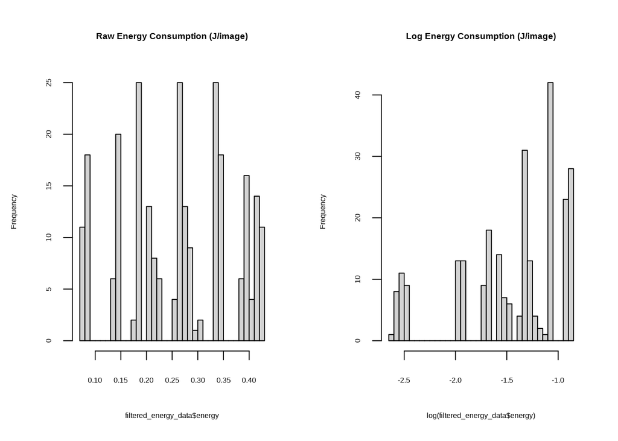

```r
par(mfrow = c(1, 2)) # Set up a 1x2 grid for histograms
hist(filtered_energy_data$energy, main = "Raw Energy Consumption (J/image)", breaks = 30)
hist(log(filtered_energy_data$energy), main = "Log Energy Consumption (J/image)", breaks = 30)
```

### Bar plot of energy consumption by architecture and training environment

```r
median_energy_by_arch_env <- filtered_energy_data %>%
  group_by(architecture, training_environment) %>%
  summarise(median_energy = median(energy, na.rm = TRUE)) %>%
  ungroup()
```

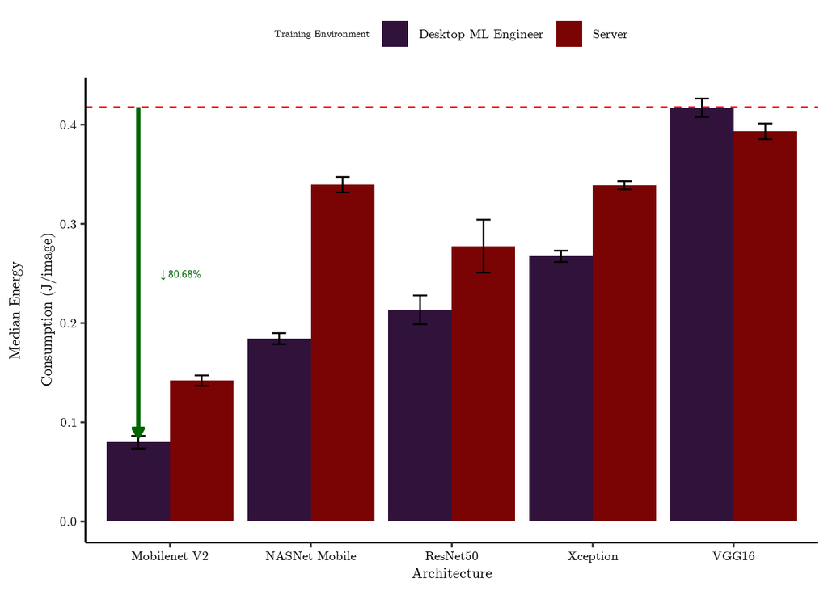

```r
greenest_architecture <- median_energy_by_arch_env %>%
  filter(median_energy == min(median_energy)) %>%
  pull(architecture) %>%
  unique()
greenest_bar_height <- median_energy_by_arch_env %>%
  filter(architecture == greenest_architecture) %>%
  summarise(min_energy = min(median_energy)) %>%
  pull(min_energy)

max_median_energy <- max(median_energy_by_arch_env$median_energy)

dodge_width <- 0.9
env_levels <- levels(factor(filtered_energy_data$training_environment)) # preserves order
target_env <- "Desktop ML Engineer"

env_index <- which(env_levels == target_env)
n_envs <- length(env_levels)
offset <- dodge_width * ((env_index - 0.5) / n_envs - 0.5)

x_base <- as.numeric(factor(greenest_architecture))
x_pos <- x_base + offset

relative_improvement <- (max_median_energy - greenest_bar_height) / max_median_energy * 100
label_text <- paste0("↓ ", formatC(relative_improvement, format = "f", digits = 2), "%")

make_energy_plot <- function(annotation_font_size = 16) {
  annottation_size <- annotation_font_size / ggplot2::.pt # Convert to relative size
  ggplot(filtered_energy_data, aes(x = architecture, y = energy, fill = training_environment)) +
    geom_bar(stat = "summary", fun = "mean", position = position_dodge()) +
    geom_errorbar(
      stat = "summary",
      fun.data = mean_sdl,
      position = position_dodge(width = 0.9),
      width = 0.2
    ) +
    # Add a horizontal line for the maximum mean energy consumption
    geom_hline(
      yintercept = max_median_energy,
      linetype = "dashed", color = "red"
    ) +
    # Add arrow pointing down
    geom_segment(
      aes(
        x = x_pos,
        xend = x_pos,
        y = max_median_energy,
        yend = greenest_bar_height + 0.005,
      ),
      arrow = arrow(length = unit(0.2, "cm"), type = "closed"),
      color = "darkgreen",
      linewidth = 1,
      alpha = 0.7,
      inherit.aes = FALSE
    ) +
    # Add text label
    annotate(
      "text",
      x = x_pos + 0.3, # horizontal offset to the right of the arrow
      y = greenest_bar_height + (max_median_energy - greenest_bar_height) / 2, # vertical midpoint
      label = label_text,
      color = "darkgreen",
      fontface = "bold",
      size = annottation_size
    ) +
    labs(
      x = "Architecture",
      y = "Median Energy\nConsumption (J/image)",
      fill = "Training Environment"
    )
}

make_energy_plot(12)
```

```r
ggsave(make_energy_plot(9) + pub_theme,
  filename = file.path(fig_dir, "energy_by_arch_and_env.pdf"),
  device = cairo_pdf,
  units = "cm",
  width = 13.71, height = 8, dpi = 300
)
```

## Linear Model

Fit a linear model to the energy consumption data, including an interaction term between architecture and training environment.

```r
model_energy <- lm(energy ~ architecture * training_environment, data = filtered_energy_data)
summary(model_energy)
```

```
##
## Call:
## lm(formula = energy ~ architecture * training_environment, data = filtered_energy_data)
##
## Residuals:
##        Min         1Q     Median         3Q        Max
## -0.0200289 -0.0025795  0.0002766  0.0028588  0.0277281
##
## Coefficients:
##                                                       Estimate Std. Error
## (Intercept)                                           0.079933   0.001067
## architectureNASNet Mobile                             0.104307   0.001537
## architectureResNet50                                  0.133359   0.001537
## architectureXception                                  0.187341   0.001537
## architectureVGG16                                     0.337076   0.001522
## training_environmentServer                            0.061994   0.001552
## architectureNASNet Mobile:training_environmentServer  0.093179   0.002338
## architectureResNet50:training_environmentServer       0.002229   0.002203
## architectureXception:training_environmentServer       0.009578   0.002225
## architectureVGG16:training_environmentServer         -0.085709   0.002241
##                                                      t value Pr(>|t|)
## (Intercept)                                           74.913  < 2e-16 ***
## architectureNASNet Mobile                             67.878  < 2e-16 ***
## architectureResNet50                                  86.785  < 2e-16 ***
## architectureXception                                 121.914  < 2e-16 ***
## architectureVGG16                                    221.412  < 2e-16 ***
## training_environmentServer                            39.947  < 2e-16 ***
## architectureNASNet Mobile:training_environmentServer  39.857  < 2e-16 ***
## architectureResNet50:training_environmentServer        1.012    0.313
## architectureXception:training_environmentServer        4.304 2.42e-05 ***
## architectureVGG16:training_environmentServer         -38.242  < 2e-16 ***
## ---
## Signif. codes:  0 '***' 0.001 '**' 0.01 '*' 0.05 '.' 0.1 ' ' 1
##
## Residual standard error: 0.005746 on 247 degrees of freedom
## Multiple R-squared:  0.9972, Adjusted R-squared:  0.9971
## F-statistic:  9740 on 9 and 247 DF,  p-value: < 2.2e-16
```

## Model diagnostics

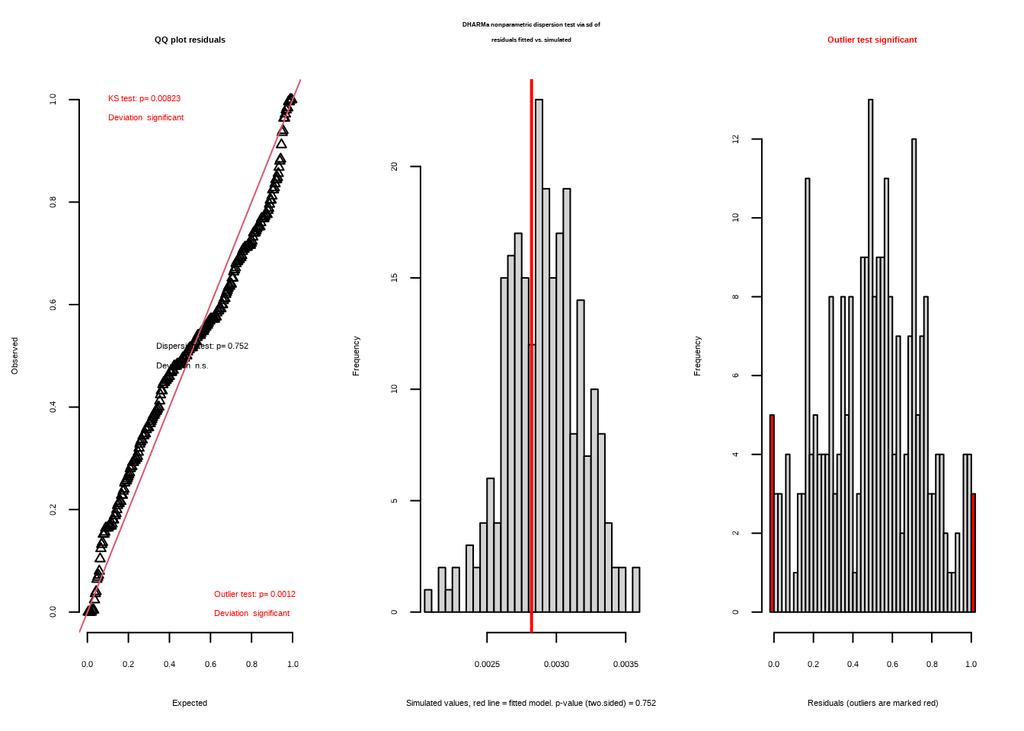

```
## $uniformity
##
##  Asymptotic one-sample Kolmogorov-Smirnov test
##
## data:  simulationOutput$scaledResiduals
## D = 0.10338, p-value = 0.00823
## alternative hypothesis: two-sided
##
##
## $dispersion
##
##  DHARMa nonparametric dispersion test via sd of residuals fitted vs.
##  simulated
##
## data:  simulationOutput
## dispersion = 0.97023, p-value = 0.752
## alternative hypothesis: two.sided
##
##
## $outliers
##
##  DHARMa outlier test based on exact binomial test with approximate
##  expectations
##
## data:  simulationOutput
## outliers at both margin(s) = 8, observations = 257, p-value = 0.001196
## alternative hypothesis: true probability of success is not equal to 0.007968127
## 95 percent confidence interval:
##  0.01353295 0.06041168
## sample estimates:
## frequency of outliers (expected: 0.00796812749003984 )
##                                              0.0311284
```

```r
sim_res_energy <- simulateResiduals(fittedModel = model_energy)
res_df <- data.frame(
  scaled_residuals = sim_res_energy$scaledResiduals,
  predicted = sim_res_energy$fittedPredictedResponse,
  observed = sim_res_energy$observedResponse
)

testResiduals(sim_res_energy)
```

### Remove the outliers detected in the residuals and refit the model

The results of the outlier test indicate that there are some outliers in the residuals. We will remove these outliers based on the scaled residuals, which are the standardized residuals from the model. We will filter out any observations with scaled residuals outside the 2.5%–97.5% quantiles.

```r
# Remove outliers based on the simulated residuals
scaled_res <- sim_res_energy$scaledResiduals

# Identify outliers: residuals outside the 2.5%–97.5% quantiles
lower <- quantile(scaled_res, 0.025)
upper <- quantile(scaled_res, 0.975)

# Mark which residuals are outside the acceptable range
outlier_index <- which(scaled_res < lower | scaled_res > upper)

filtered_energy_data <- filtered_energy_data[-outlier_index, ]

# Show the outliers
filtered_energy_data[outlier_index, ]
```

| energy | gpu_usage | architecture | training_environment |
| --- | --- | --- | --- |
| 0.2088126 | 89.64469 | ResNet50 | Desktop ML Engineer |
| 0.2079202 | 89.83366 | ResNet50 | Desktop ML Engineer |
| 0.2170670 | 90.09431 | ResNet50 | Desktop ML Engineer |
| 0.2784353 | 79.55997 | ResNet50 | Server |
| 0.2791467 | 78.44797 | ResNet50 | Server |
| 0.2837240 | 79.80957 | ResNet50 | Server |
| 0.2751249 | 79.87418 | ResNet50 | Server |
| 0.3959175 | 89.91812 | VGG16 | Server |
| 0.3919862 | 89.98657 | VGG16 | Server |
| 0.3882137 | 89.90713 | VGG16 | Server |

[output cut: 2 more lines]

Refit the model after removing outliers

```r
model_energy <- lm(energy ~ architecture * training_environment, data = filtered_energy_data)
summary(model_energy)
```

```
##
## Call:
## lm(formula = energy ~ architecture * training_environment, data = filtered_energy_data)
##
## Residuals:
##        Min         1Q     Median         3Q        Max
## -0.0152300 -0.0025378  0.0002993  0.0026764  0.0124266
##
## Coefficients:
##                                                        Estimate Std. Error
## (Intercept)                                           0.0799325  0.0007766
## architectureNASNet Mobile                             0.1043066  0.0011184
## architectureResNet50                                  0.1319162  0.0011540
## architectureXception                                  0.1873410  0.0011184
## architectureVGG16                                     0.3370760  0.0011080
## training_environmentServer                            0.0619942  0.0011295
## architectureNASNet Mobile:training_environmentServer  0.0931789  0.0017015
## architectureResNet50:training_environmentServer       0.0041419  0.0017251
## architectureXception:training_environmentServer       0.0095777  0.0016196
## architectureVGG16:training_environmentServer         -0.0857086  0.0016312
##                                                      t value Pr(>|t|)
## (Intercept)                                          102.930  < 2e-16 ***
## architectureNASNet Mobile                             93.265  < 2e-16 ***
## architectureResNet50                                 114.310  < 2e-16 ***
## architectureXception                                 167.510  < 2e-16 ***
## architectureVGG16                                    304.221  < 2e-16 ***
## training_environmentServer                            54.888  < 2e-16 ***
## architectureNASNet Mobile:training_environmentServer  54.764  < 2e-16 ***
## architectureResNet50:training_environmentServer        2.401   0.0171 *
## architectureXception:training_environmentServer        5.914 1.17e-08 ***
## architectureVGG16:training_environmentServer         -52.545  < 2e-16 ***
## ---
## Signif. codes:  0 '***' 0.001 '**' 0.01 '*' 0.05 '.' 0.1 ' ' 1
##
## Residual standard error: 0.004182 on 235 degrees of freedom
## Multiple R-squared:  0.9986, Adjusted R-squared:  0.9985
## F-statistic: 1.835e+04 on 9 and 235 DF,  p-value: < 2.2e-16
```

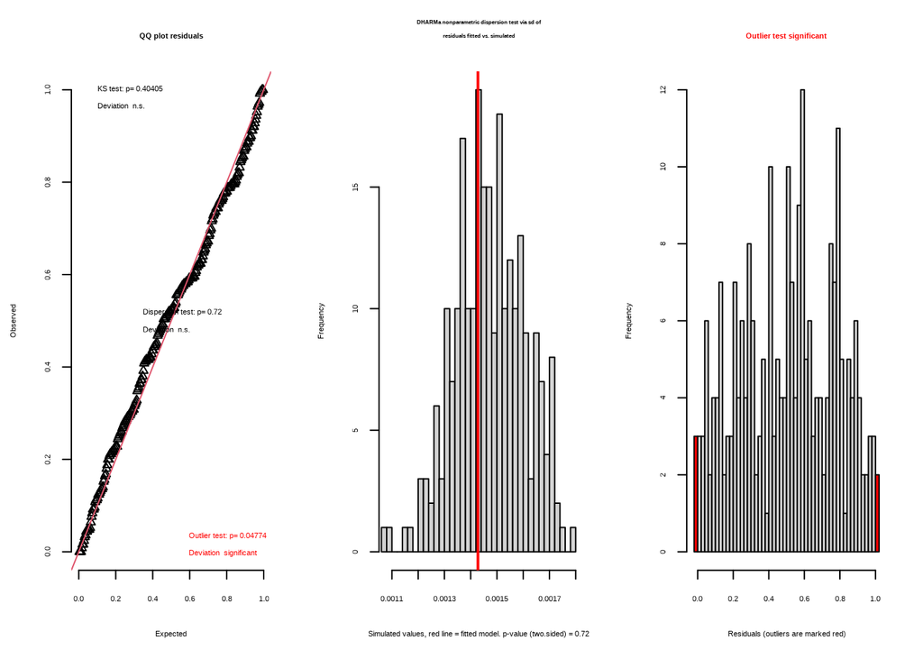

```
## $uniformity
##
##  Asymptotic one-sample Kolmogorov-Smirnov test
##
## data:  simulationOutput$scaledResiduals
## D = 0.05698, p-value = 0.4041
## alternative hypothesis: two-sided
##
##
## $dispersion
##
##  DHARMa nonparametric dispersion test via sd of residuals fitted vs.
##  simulated
##
## data:  simulationOutput
## dispersion = 0.96941, p-value = 0.72
## alternative hypothesis: two.sided
##
##
## $outliers
##
##  DHARMa outlier test based on exact binomial test with approximate
##  expectations
##
## data:  simulationOutput
## outliers at both margin(s) = 5, observations = 245, p-value = 0.04774
## alternative hypothesis: true probability of success is not equal to 0.007968127
## 95 percent confidence interval:
##  0.006658888 0.046980597
## sample estimates:
## frequency of outliers (expected: 0.00796812749003984 )
##                                             0.02040816
```

```r
sim_res_energy <- simulateResiduals(fittedModel = model_energy)

testResiduals(sim_res_energy)
```

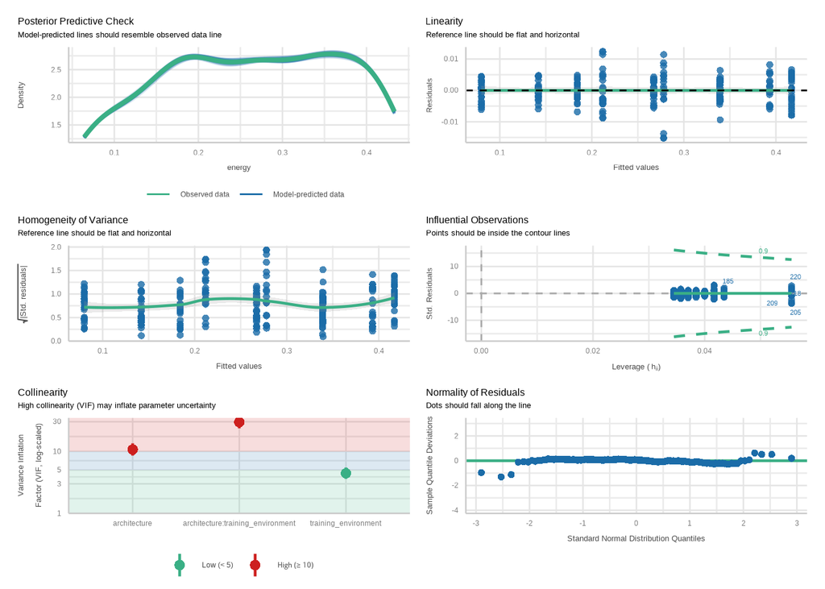

```r
check_model(model_energy)
```

## Significance testing

```r
options(contrasts = c("contr.sum", "contr.poly")) # sum-to-zero contrasts for Type III
Anova(model_energy, type = 3)
```

|  | Sum Sq | Df | F value | Pr(>F) |
| --- | --- | --- | --- | --- |
| (Intercept) | 0.185287097 | 1 | 10594.655 | 1.794422e-197 |
| architecture | 1.733909835 | 4 | 24786.097 | 3.096384e-307 |
| training_environment | 0.052687842 | 1 | 3012.673 | 5.282450e-136 |
| architecture:training_environment | 0.187759901 | 4 | 2684.012 | 8.624049e-195 |
| Residuals | 0.004109852 | 235 | NA | NA |

```r
effectsize::eta_squared(model_energy, partial = FALSE)  # for eta-squared
```

| Parameter | Eta2 | CI | CI_low | CI_high |
| --- | --- | --- | --- | --- |
| architecture | 0.84946299 | 0.95 | 0.82368855 | 1 |
| training_environment | 0.08420417 | 0.95 | 0.03597516 | 1 |
| architecture:training_environment | 0.06491199 | 0.95 | 0.01371165 | 1 |

```r
effectsize::eta_squared(model_energy, partial = TRUE)  # for partial eta-squared
```

| Parameter | Eta2_partial | CI | CI_low | CI_high |
| --- | --- | --- | --- | --- |
| architecture | 0.9983301 | 0.95 | 0.9980429 | 1 |
| training_environment | 0.9834061 | 0.95 | 0.9805542 | 1 |
| architecture:training_environment | 0.9785800 | 0.95 | 0.9748916 | 1 |

## Post hoc tests

```r
emm_energy <- emmeans(model_energy, ~ architecture * training_environment, type = "response")
pair_comparison <- pairs(emm_energy, type = "response")

# To view results:
summary(emm_energy)
```

|  | architecture | training_environment | emmean | SE | df | lower.CL | upper.CL |
| --- | --- | --- | --- | --- | --- | --- | --- |
| 1 | Mobilenet V2 | Desktop ML Engineer | 0.07993254 | 0.0007765692 | 235 | 0.07840261 | 0.08146246 |
| 2 | NASNet Mobile | Desktop ML Engineer | 0.18423912 | 0.0008048173 | 235 | 0.18265354 | 0.18582470 |
| 3 | ResNet50 | Desktop ML Engineer | 0.21184879 | 0.0008536377 | 235 | 0.21016702 | 0.21353055 |
| 4 | Xception | Desktop ML Engineer | 0.26727358 | 0.0008048173 | 235 | 0.26568800 | 0.26885916 |
| 5 | VGG16 | Desktop ML Engineer | 0.41700852 | 0.0007903149 | 235 | 0.41545151 | 0.41856553 |
| 6 | Mobilenet V2 | Server | 0.14192671 | 0.0008201485 | 235 | 0.14031093 | 0.14354249 |
| 7 | NASNet Mobile | Server | 0.33941224 | 0.0009856959 | 235 | 0.33747031 | 0.34135417 |
| 8 | ResNet50 | Server | 0.27798485 | 0.0009856959 | 235 | 0.27604292 | 0.27992678 |
| 9 | Xception | Server | 0.33884544 | 0.0008363907 | 235 | 0.33719766 | 0.34049322 |
| 10 | VGG16 | Server | 0.39329414 | 0.0008719976 | 235 | 0.39157620 | 0.39501207 |

```r
summary(pair_comparison)
```

|  | contrast | estimate | SE | df | t.ratio | p.value |
| --- | --- | --- | --- | --- | --- | --- |
| 1 | Mobilenet V2 Desktop ML Engineer - NASNet Mobile Desktop ML Engineer | -0.1043065865 | 0.001118388 | 235 | -93.2651549 | 4.440892e-15 |
| 2 | Mobilenet V2 Desktop ML Engineer - ResNet50 Desktop ML Engineer | -0.1319162496 | 0.001154018 | 235 | -114.3104135 | 4.440892e-15 |
| 3 | Mobilenet V2 Desktop ML Engineer - Xception Desktop ML Engineer | -0.1873410428 | 0.001118388 | 235 | -167.5099527 | 4.440892e-15 |
| 4 | Mobilenet V2 Desktop ML Engineer - VGG16 Desktop ML Engineer | -0.3370759866 | 0.001107997 | 235 | -304.2210188 | 4.440892e-15 |
| 5 | Mobilenet V2 Desktop ML Engineer - Mobilenet V2 Server | -0.0619941741 | 0.001129470 | 235 | -54.8878250 | 4.440892e-15 |
| 6 | Mobilenet V2 Desktop ML Engineer - NASNet Mobile Server | -0.2594797066 | 0.001254853 | 235 | -206.7809547 | 4.440892e-15 |
| 7 | Mobilenet V2 Desktop ML Engineer - ResNet50 Server | -0.1980523115 | 0.001254853 | 235 | -157.8290903 | 4.440892e-15 |
| 8 | Mobilenet V2 Desktop ML Engineer - Xception Server | -0.2589129056 | 0.001141319 | 235 | -226.8541022 | 4.440892e-15 |
| 9 | Mobilenet V2 Desktop ML Engineer - VGG16 Server | -0.3133615999 | 0.001167664 | 235 | -268.3662120 | 4.440892e-15 |
| 10 | NASNet Mobile Desktop ML Engineer - ResNet50 Desktop ML Engineer | -0.0276096630 | 0.001173213 | 235 | -23.5333816 | 4.440892e-15 |

[output cut: 35 more lines]

```r
print("Non-significant pairwise comparisons:")
```

```
## [1] "Non-significant pairwise comparisons:"
```

```r
pair_comparison_df <- as.data.frame(pair_comparison)
pair_comparison_df %>%
  filter(p.value > 0.05) %>%
  select(contrast, estimate, SE, df, t.ratio, p.value)
```

| contrast | estimate | SE | df | t.ratio | p.value |
| --- | --- | --- | --- | --- | --- |
| NASNet Mobile Server - Xception Server | 0.0005668011 | 0.001292728 | 235 | 0.4384535 | 0.9999902 |

Plot the interaction effects

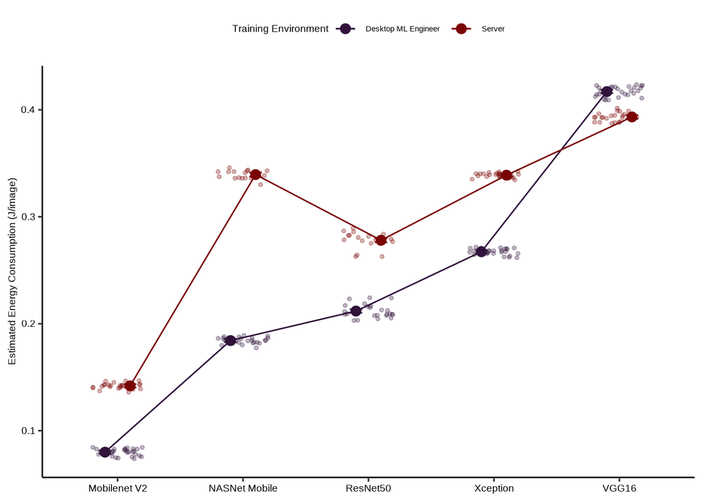

```r
emm_energy_df <- as.data.frame(emm_energy)
emm_df <- emm_energy_df %>%
  mutate(
    energy_estimate = emmean,
    lower_CI = lower.CL,
    upper_CI = upper.CL
  )

# Set the desired order for the x axis
emm_df$architecture <- factor(emm_df$architecture, levels = c("Mobilenet V2", "NASNet Mobile", "ResNet50", "Xception", "VGG16"))

ggplot() +
  # Raw data jittered
  geom_jitter(
    data = filtered_energy_data,
    aes(x = architecture, y = energy, color = training_environment),
    width = 0.2, alpha = 0.3, size = 1
  ) +
  # Estimated points
  geom_point(
    data = emm_df,
    aes(x = architecture, y = energy_estimate, color = training_environment, group = training_environment),
    size = 3, position = position_dodge(width = 0.4)
  ) +
  # Lines connecting estimated points
  geom_line(
    data = emm_df,
    aes(x = architecture, y = energy_estimate, color = training_environment, group = training_environment),
    position = position_dodge(width = 0.4)
  ) +
  # Error bars
  geom_errorbar(
    data = emm_df,
    aes(x = architecture, ymin = lower_CI, ymax = upper_CI, color = training_environment, group = training_environment),
    width = 0.2, position = position_dodge(width = 0.4)
  ) +
  labs(
    title = NULL,
    x = NULL,
    y = "Estimated Energy Consumption (J/image)",
    color = "Training Environment"
  ) +
  theme_pubr() +
  theme(text = element_text(size = 14))
```

# GPU Usage Analysis

## Data summary

```r
filtered_gpu_data %>%
  group_by(architecture, training_environment) %>%
  summarise(
    mean_gpu_usage = mean(gpu_usage, na.rm = TRUE),
    sd_gpu_usage = sd(gpu_usage, na.rm = TRUE),
    min_gpu_usage = min(gpu_usage, na.rm = TRUE),
    max_gpu_usage = max(gpu_usage, na.rm = TRUE),
    n = n()
  )
```

| architecture | training_environment | mean_gpu_usage | sd_gpu_usage | min_gpu_usage | max_gpu_usage | n |
| --- | --- | --- | --- | --- | --- | --- |
| Mobilenet V2 | Desktop ML Engineer | 56.00382 | 1.5930925 | 52.51105 | 59.44064 | 29 |
| Mobilenet V2 | Server | 22.80200 | 0.3866662 | 21.74599 | 23.46073 | 25 |
| NASNet Mobile | Desktop ML Engineer | 77.34079 | 1.0806131 | 75.73429 | 79.59898 | 27 |
| NASNet Mobile | Server | 42.25492 | 0.4968451 | 41.15118 | 43.11152 | 16 |
| ResNet50 | Desktop ML Engineer | 90.04642 | 0.7515370 | 88.72971 | 91.45865 | 27 |
| ResNet50 | Server | 78.36417 | 1.2160070 | 76.47336 | 80.55567 | 24 |
| Xception | Desktop ML Engineer | 92.93294 | 0.2535415 | 92.50332 | 93.53525 | 27 |
| Xception | Server | 59.61518 | 0.4722327 | 58.62143 | 60.30577 | 27 |
| VGG16 | Desktop ML Engineer | 95.65999 | 0.1141640 | 95.42987 | 95.85964 | 27 |
| VGG16 | Server | 90.00546 | 0.3072382 | 89.52644 | 90.65951 | 24 |

## Visualize the data

### Histograms of GPU usage

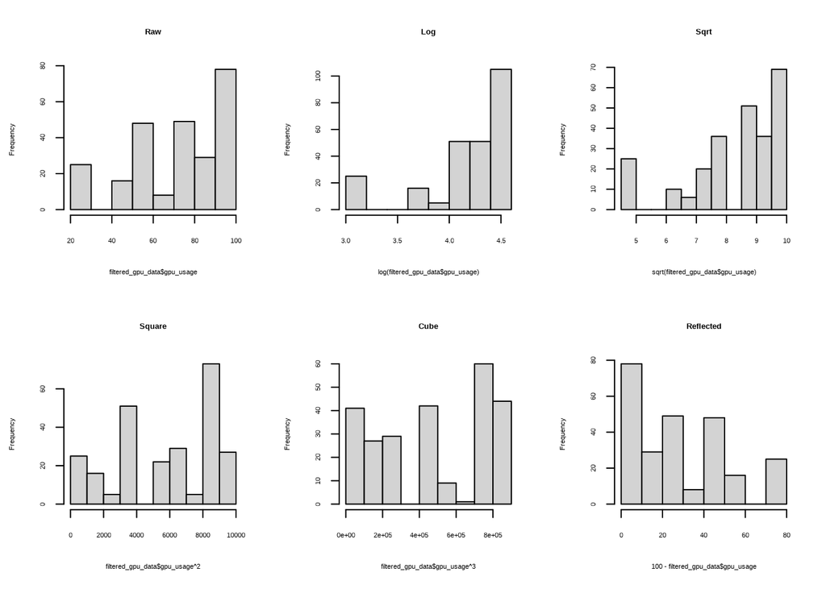

```r
par(mfrow = c(2, 3)) # Set up a 2x3 grid for histograms
hist(filtered_gpu_data$gpu_usage, main = "Raw")
hist(log(filtered_gpu_data$gpu_usage), main = "Log")
hist(sqrt(filtered_gpu_data$gpu_usage), main = "Sqrt")
hist(filtered_gpu_data$gpu_usage^2, main = "Square")
hist(filtered_gpu_data$gpu_usage^3, main = "Cube")
hist(100 - filtered_gpu_data$gpu_usage, main = "Reflected")
```

### Bar plot of GPU usage by architecture and training environment

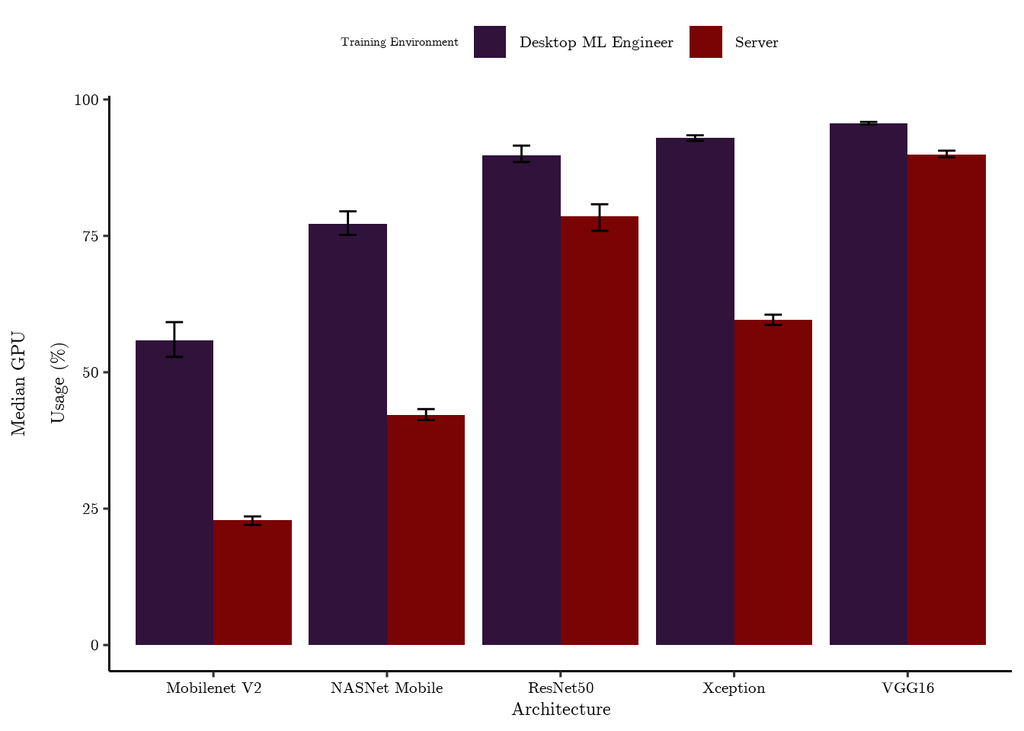

```r
gpu_barplot <- ggplot(filtered_gpu_data, aes(x = architecture, y = gpu_usage, fill = training_environment)) +
  geom_bar(stat = "summary", fun = "median", position = position_dodge()) +
  geom_errorbar(
    stat = "summary",
    fun.data = mean_sdl,
    position = position_dodge(width = 0.9),
    width = 0.2
  ) +
  labs(
    x = "Architecture",
    y = "Median GPU\nUsage (%)",
    fill = "Training Environment"
  )

gpu_barplot
```

```r
ggsave(gpu_barplot + pub_theme,
  filename = file.path(fig_dir, "gpu_usage_barplot.pdf"),
  device = cairo_pdf,
  units = "cm",
  width = 13.71, height = 8, dpi = 300
)
```

## Linear Model

```r
max_val <- 100
filtered_gpu_data$gpu_usage_reflected <- sqrt(max_val - filtered_gpu_data$gpu_usage + 1)

model_gpu <- lm(gpu_usage_reflected ~ architecture * training_environment, data = filtered_gpu_data)
summary(model_gpu)
```

```
##
## Call:
## lm(formula = gpu_usage_reflected ~ architecture * training_environment,
##     data = filtered_gpu_data)
##
## Residuals:
##      Min       1Q   Median       3Q      Max
## -0.26025 -0.03082  0.00318  0.03812  0.25650
##
## Coefficients:
##                                      Estimate Std. Error  t value Pr(>|t|)
## (Intercept)                          5.104004   0.005199  981.683  < 2e-16 ***
## architecture1                        2.670915   0.010075  265.096  < 2e-16 ***
## architecture2                        1.159646   0.011250  103.079  < 2e-16 ***
## architecture3                       -1.072117   0.010283 -104.265  < 2e-16 ***
## architecture4                       -0.467544   0.010055  -46.499  < 2e-16 ***
## training_environment1               -1.098389   0.005199 -211.260  < 2e-16 ***
## architecture1:training_environment1  0.030370   0.010075    3.014  0.00285 **
## architecture2:training_environment1 -0.302430   0.011250  -26.883  < 2e-16 ***
## architecture3:training_environment1  0.374211   0.010283   36.393  < 2e-16 ***
## architecture4:training_environment1 -0.698154   0.010055  -69.434  < 2e-16 ***
## ---
## Signif. codes:  0 '***' 0.001 '**' 0.01 '*' 0.05 '.' 0.1 ' ' 1
##
## Residual standard error: 0.08165 on 243 degrees of freedom
## Multiple R-squared:  0.9985, Adjusted R-squared:  0.9985
## F-statistic: 1.819e+04 on 9 and 243 DF,  p-value: < 2.2e-16
```

## Model diagnostics

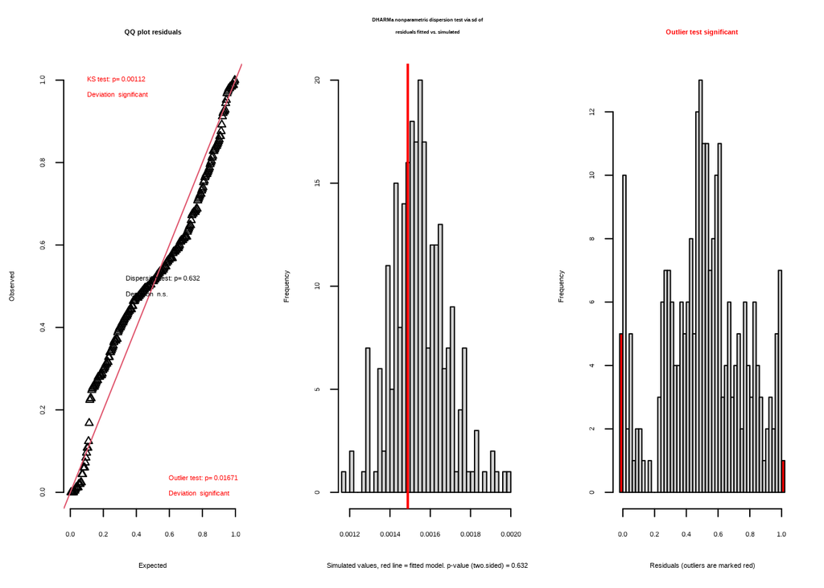

```
## $uniformity
##
##  Asymptotic one-sample Kolmogorov-Smirnov test
##
## data:  simulationOutput$scaledResiduals
## D = 0.12161, p-value = 0.001125
## alternative hypothesis: two-sided
##
##
## $dispersion
##
##  DHARMa nonparametric dispersion test via sd of residuals fitted vs.
##  simulated
##
## data:  simulationOutput
## dispersion = 0.9612, p-value = 0.632
## alternative hypothesis: two.sided
##
##
## $outliers
##
##  DHARMa outlier test based on exact binomial test with approximate
##  expectations
##
## data:  simulationOutput
## outliers at both margin(s) = 6, observations = 253, p-value = 0.01671
## alternative hypothesis: true probability of success is not equal to 0.007968127
## 95 percent confidence interval:
##  0.008751744 0.050901125
## sample estimates:
## frequency of outliers (expected: 0.00796812749003984 )
##                                             0.02371542
```

```r
sim_res_gpu <- simulateResiduals(fittedModel = model_gpu)
testResiduals(sim_res_gpu)
```

### Remove the outliers detected in the residuals and refit the model

The results of the outlier test indicate that there are some outliers in the residuals. We will remove these outliers based on the scaled residuals, which are the standardized residuals from the model. We will filter out any observations with scaled residuals outside the 2.5%–97.5% quantiles.

```r
# Remove outliers based on the simulated residuals
scaled_res_gpu <- sim_res_gpu$scaledResiduals
# Identify outliers: residuals outside the 2.5%–97.5% quantiles
lower_gpu <- quantile(scaled_res_gpu, 0.025)
upper_gpu <- quantile(scaled_res_gpu, 0.975)
# Mark which residuals are outside the acceptable range
outlier_index_gpu <- which(scaled_res_gpu < lower_gpu | scaled_res_gpu > upper_gpu)
filtered_gpu_data <- filtered_gpu_data[-outlier_index_gpu, ]
# Show the outliers
filtered_gpu_data[outlier_index_gpu, ]
```

| energy | gpu_usage | architecture | training_environment | gpu_usage_reflected |
| --- | --- | --- | --- | --- |
| 0.07381506 | 58.27013 | Mobilenet V2 | Desktop ML Engineer | 6.536809 |
| 0.08438807 | 55.50543 | Mobilenet V2 | Desktop ML Engineer | 6.744966 |
| 0.18458323 | 76.43430 | NASNet Mobile | Desktop ML Engineer | 4.956379 |
| 0.18449919 | 76.41546 | NASNet Mobile | Desktop ML Engineer | 4.958280 |
| 0.18430524 | 75.73429 | NASNet Mobile | Desktop ML Engineer | 5.026501 |
| 0.21507212 | 89.75678 | ResNet50 | Desktop ML Engineer | 3.353091 |
| 0.20868569 | 89.39193 | ResNet50 | Desktop ML Engineer | 3.407061 |
| 0.20522574 | 89.78299 | ResNet50 | Desktop ML Engineer | 3.349181 |
| 0.20792025 | 89.83366 | ResNet50 | Desktop ML Engineer | 3.341607 |
| 0.28677109 | 78.82763 | ResNet50 | Server | 4.708754 |

[output cut: 2 more lines]

Refit the model after removing outliers

```r
model_gpu <- lm(gpu_usage_reflected ~ architecture * training_environment, data = filtered_gpu_data)
summary(model_gpu)
```

```
##
## Call:
## lm(formula = gpu_usage_reflected ~ architecture * training_environment,
##     data = filtered_gpu_data)
##
## Residuals:
##       Min        1Q    Median        3Q       Max
## -0.238509 -0.028272  0.003159  0.029850  0.202503
##
## Coefficients:
##                                      Estimate Std. Error  t value Pr(>|t|)
## (Intercept)                          5.106478   0.004407 1158.695  < 2e-16 ***
## architecture1                        2.668510   0.008498  314.004  < 2e-16 ***
## architecture2                        1.163544   0.009530  122.096  < 2e-16 ***
## architecture3                       -1.068663   0.009048 -118.116  < 2e-16 ***
## architecture4                       -0.470018   0.008378  -56.101  < 2e-16 ***
## training_environment1               -1.094689   0.004407 -248.392  < 2e-16 ***
## architecture1:training_environment1  0.026740   0.008498    3.146  0.00187 **
## architecture2:training_environment1 -0.299759   0.009530  -31.455  < 2e-16 ***
## architecture3:training_environment1  0.382569   0.009048   42.284  < 2e-16 ***
## architecture4:training_environment1 -0.701854   0.008378  -83.774  < 2e-16 ***
## ---
## Signif. codes:  0 '***' 0.001 '**' 0.01 '*' 0.05 '.' 0.1 ' ' 1
##
## Residual standard error: 0.0676 on 231 degrees of freedom
## Multiple R-squared:  0.999,  Adjusted R-squared:  0.999
## F-statistic: 2.608e+04 on 9 and 231 DF,  p-value: < 2.2e-16
```

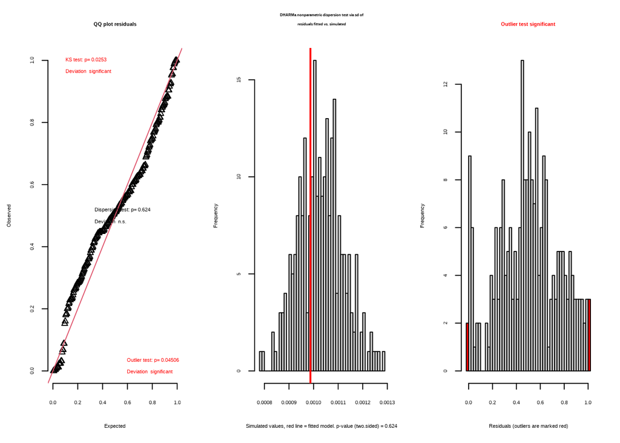

```
## $uniformity
##
##  Asymptotic one-sample Kolmogorov-Smirnov test
##
## data:  simulationOutput$scaledResiduals
## D = 0.09522, p-value = 0.0253
## alternative hypothesis: two-sided
##
##
## $dispersion
##
##  DHARMa nonparametric dispersion test via sd of residuals fitted vs.
##  simulated
##
## data:  simulationOutput
## dispersion = 0.95842, p-value = 0.624
## alternative hypothesis: two.sided
##
##
## $outliers
##
##  DHARMa outlier test based on exact binomial test with approximate
##  expectations
##
## data:  simulationOutput
## outliers at both margin(s) = 5, observations = 241, p-value = 0.04506
## alternative hypothesis: true probability of success is not equal to 0.007968127
## 95 percent confidence interval:
##  0.006769961 0.047749520
## sample estimates:
## frequency of outliers (expected: 0.00796812749003984 )
##                                             0.02074689
```

```r
sim_res_gpu <- simulateResiduals(fittedModel = model_gpu)
testResiduals(sim_res_gpu)
```

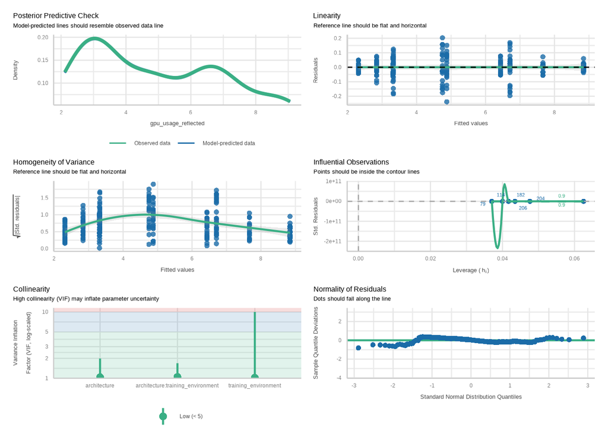

```r
check_model(model_gpu)
```

## Significance testing

```r
options(contrasts = c("contr.sum", "contr.poly")) # sum-to-zero contrasts for Type III
Anova(model_gpu, type = 3)
```

|  | Sum Sq | Df | F value | Pr(>F) |
| --- | --- | --- | --- | --- |
| (Intercept) | 6134.419693 | 1 | 1342573.819 | 0.000000e+00 |
| architecture | 750.981248 | 4 | 41089.778 | 0.000000e+00 |
| training_environment | 281.911067 | 1 | 61698.814 | 1.791548e-282 |
| architecture:training_environment | 54.339271 | 4 | 2973.162 | 2.486489e-197 |
| Residuals | 1.055473 | 231 | NA | NA |

```r
effectsize::eta_squared(model_gpu, partial = FALSE)  # for eta-squared
```

| Parameter | Eta2 | CI | CI_low | CI_high |
| --- | --- | --- | --- | --- |
| architecture | 0.67920920 | 0.95 | 0.626043636 | 1 |
| training_environment | 0.26918233 | 0.95 | 0.192687076 | 1 |
| architecture:training_environment | 0.05062514 | 0.95 | 0.005156636 | 1 |

```r
effectsize::eta_squared(model_gpu, partial = TRUE)  # for partial eta-squared
```

| Parameter | Eta2_partial | CI | CI_low | CI_high |
| --- | --- | --- | --- | --- |
| architecture | 0.9985543 | 0.95 | 0.9983032 | 1 |
| training_environment | 0.9963603 | 0.95 | 0.9957282 | 1 |
| architecture:training_environment | 0.9809463 | 0.95 | 0.9776337 | 1 |

## Post hoc tests

```r
emm_gpu <- emmeans(model_gpu, ~ architecture * training_environment)

# back-transform estimated means
emm_gpu_df <- as.data.frame(emm_gpu)
emm_gpu_df <- emm_gpu_df %>%
  mutate(
    gpu_estimate = max_val - emmean^2 + 1,
    lower_CI = max_val - (emmean + SE * qt(0.975, df))^2 + 1,
    upper_CI = max_val - (emmean - SE * qt(0.975, df))^2 + 1
  )

emm_gpu_df
```

|  | architecture | training_environment | emmean | SE | df | lower.CL | upper.CL | gpu_estimate | lower_CI | upper_CI |
| --- | --- | --- | --- | --- | --- | --- | --- | --- | --- | --- |
| 1 | Mobilenet V2 | Desktop ML Engineer | 6.707039 | 0.01300876 | 231 | 6.681408 | 6.732670 | 56.01563 | 55.67116 | 56.35879 |
| 2 | NASNet Mobile | Desktop ML Engineer | 4.875574 | 0.01379787 | 231 | 4.848388 | 4.902760 | 77.22878 | 76.96295 | 77.49313 |
| 3 | ResNet50 | Desktop ML Engineer | 3.325695 | 0.01409463 | 231 | 3.297925 | 3.353466 | 89.93975 | 89.75427 | 90.12369 |
| 4 | Xception | Desktop ML Engineer | 2.839917 | 0.01300876 | 231 | 2.814286 | 2.865548 | 92.93487 | 92.78864 | 93.07980 |
| 5 | VGG16 | Desktop ML Engineer | 2.310719 | 0.01300876 | 231 | 2.285088 | 2.336350 | 95.66058 | 95.54147 | 95.77837 |
| 6 | Mobilenet V2 | Server | 8.842938 | 0.01351910 | 231 | 8.816301 | 8.869574 | 22.80246 | 22.33066 | 23.27284 |
| 7 | NASNet Mobile | Server | 7.664470 | 0.01689887 | 231 | 7.631174 | 7.697765 | 42.25591 | 41.74441 | 42.76518 |
| 8 | ResNet50 | Server | 4.749935 | 0.01475054 | 231 | 4.720872 | 4.778998 | 78.43812 | 78.16118 | 78.71337 |
| 9 | Xception | Server | 6.433003 | 0.01300876 | 231 | 6.407372 | 6.458634 | 59.61647 | 59.28605 | 59.94558 |
| 10 | VGG16 | Server | 3.315490 | 0.01379787 | 231 | 3.288304 | 3.342676 | 90.00753 | 89.82652 | 90.18705 |

```r
emm_pairs_gpu <- pairs(emm_gpu, type = "response")

emm_pairs_gpu_df <- as.data.frame(emm_pairs_gpu)

print("Non-significant pairwise comparisons:")
```

```
## [1] "Non-significant pairwise comparisons:"
```

```r
emm_pairs_gpu_df %>%
  filter(p.value > 0.05) %>%
  select(contrast, estimate, SE, df, t.ratio, p.value)
```

| contrast | estimate | SE | df | t.ratio | p.value |
| --- | --- | --- | --- | --- | --- |
| ResNet50 Desktop ML Engineer - VGG16 Server | 0.01020535 | 0.01972409 | 231 | 0.5174053 | 0.9999594 |

Plot the interaction effects

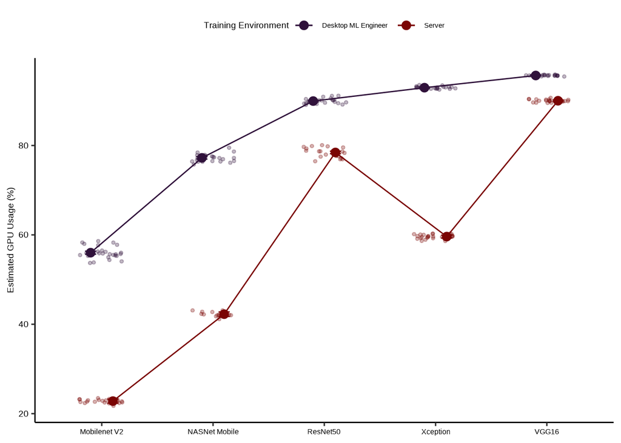

```r
# Set the desired order for the x axis
emm_gpu_df$architecture <- factor(emm_gpu_df$architecture, levels = c("Mobilenet V2", "NASNet Mobile", "ResNet50", "Xception", "VGG16"))

ggplot() +
  # Raw data jittered
  geom_jitter(
    data = filtered_gpu_data,
    aes(x = architecture, y = gpu_usage, color = training_environment),
    width = 0.2, alpha = 0.3, size = 1
  ) +
  # Estimated points
  geom_point(
    data = emm_gpu_df,
    aes(x = architecture, y = gpu_estimate, color = training_environment, group = training_environment),
    size = 3, position = position_dodge(width = 0.4)
  ) +
  # Line connecting the points
  geom_line(
    data = emm_gpu_df,
    aes(x = architecture, y = gpu_estimate, color = training_environment, group = training_environment),
    position = position_dodge(width = 0.4)
  ) +
  # Error bars
  geom_errorbar(
    data = emm_gpu_df,
    aes(x = architecture, ymin = lower_CI, ymax = upper_CI, color = training_environment, group = training_environment),
    width = 0.2, position = position_dodge(width = 0.4)
  ) +
  labs(
    title = NULL,
    x = NULL,
    y = "Estimated GPU Usage (%)",
    color = "Training Environment"
  ) +
  theme_pubr() +
  theme(
    text = element_text(size = 14),
    axis.text.x = element_text(size = 12)
  )
```

## Visualize estimated energy consumption and gpu usage by architecture and training environment

Show the estimated energy consumption and GPU usage by architecture and training environment in two plots side by side.

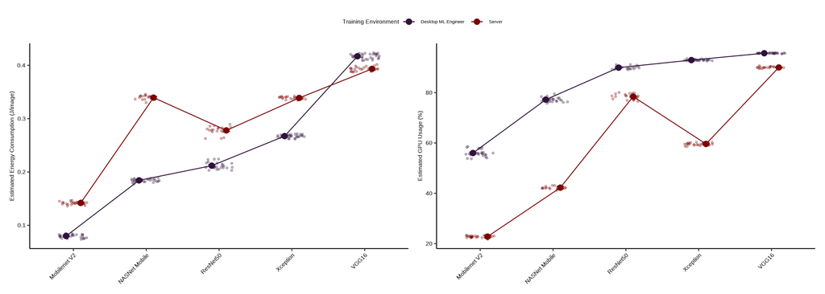

```r
energy_plot <- ggplot() +
  geom_jitter(
    data = filtered_energy_data,
    aes(x = architecture, y = energy, color = training_environment),
    width = 0.2, alpha = 0.3, size = 1
  ) +
  geom_point(
    data = emm_df,
    aes(x = architecture, y = energy_estimate, color = training_environment, group = training_environment),
    size = 3, position = position_dodge(width = 0.4)
  ) +
  geom_line(
    data = emm_df,
    aes(x = architecture, y = energy_estimate, color = training_environment, group = training_environment),
    position = position_dodge(width = 0.4)
  ) +
  geom_errorbar(
    data = emm_df,
    aes(x = architecture, ymin = lower_CI, ymax = upper_CI, color = training_environment, group = training_environment),
    width = 0.2, position = position_dodge(width = 0.4)
  ) +
  labs(
    title = NULL,
    x = NULL,
    y = "Estimated Energy Consumption (J/image)",
    color = "Training Environment"
  ) +
  theme_pubr() +
  theme(
    text = element_text(size = 14),
    axis.text.x = element_text(angle = 45, hjust = 1)
  )
# Create the GPU usage plot
gpu_plot <- ggplot() +
  geom_jitter(
    data = filtered_gpu_data,
    aes(x = architecture, y = gpu_usage, color = training_environment),
    width = 0.2, alpha = 0.3, size = 1
  ) +
  geom_point(
    data = emm_gpu_df,
    aes(x = architecture, y = gpu_estimate, color = training_environment, group = training_environment),
    size = 3, position = position_dodge(width = 0.4)
  ) +
  geom_line(
    data = emm_gpu_df,
    aes(x = architecture, y = gpu_estimate, color = training_environment, group = training_environment),
    position = position_dodge(width = 0.4)
  ) +
  geom_errorbar(
    data = emm_gpu_df,
    aes(x = architecture, ymin = lower_CI, ymax = upper_CI, color = training_environment, group = training_environment),
    width = 0.2, position = position_dodge(width = 0.4)
  ) +
  labs(
    title = NULL,
    x = NULL,
    y = "Estimated GPU Usage (%)",
    color = "Training Environment"
  ) +
  theme_pubr() +
  theme(
    text = element_text(size = 14),
    axis.text.x = element_text(angle = 45, hjust = 1)
  )
# grid.arrange(energy_plot, gpu_plot, ncol = 2)

(energy_plot | gpu_plot) +
  plot_layout(guides = "collect") &
  theme(legend.position = "top")
```